# Learning Week 7: Opioid crisis

PHRM3302 Tutorial

### Learning objectives for the week

1. Analyse the objectives and outcomes of the PBS subsidised take home naloxone pilot
2. Evaluate the role of take home naloxone in reducing opioid-related harm
3. Identify the facilitators and barriers of pharmacy supply of take home naloxone and propose strategies to improve outcomes

### Extend activities

- Objectives and outcomes of the pilot Take Home Naloxone program (ET)
- Naloxone use (ET)

### Take home naloxone

1. Evaluate the clinical impact of the PBS-subsidised take home naloxone provided in the pilot
2. Analyse the benefits of having community pharmacies involved in supply of take home naloxone
3. Identify barriers to the supply of take home naloxone in pharmacy and propose strategies to overcome the barriers.
4. Identify opportunities for the supply of take home naloxone in pharmacy and propose strategies to realise these opportunities

### Opportunities

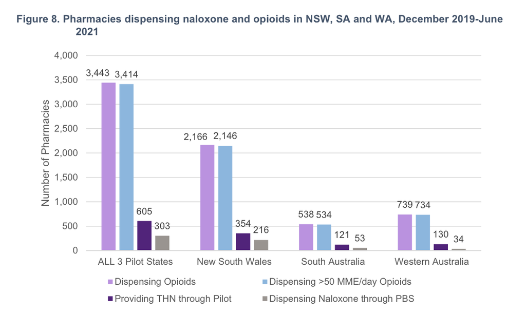

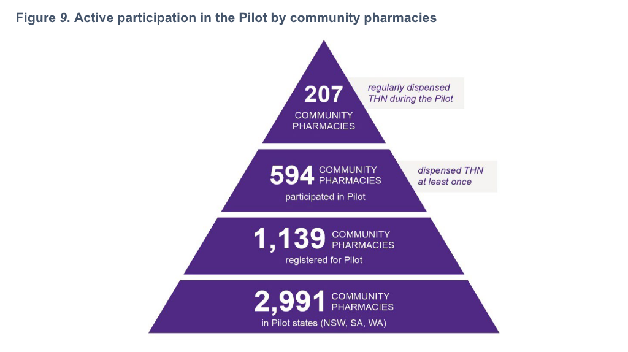

### Case

Samara Aktari is a regular customer in your pharmacy.

Samara is 35 and dotes on her three children, aged 11, 10 and 7.

Samara suffers regular migraines and depression. Samara presents to the pharmacy with a prescription for the following treatments

1. Nitrazepam 5mg 25, “Take mdu”
2. Mersyndol Forte 20, “Take mdu”
3. Tramadol SR 200mg 10, “1 d”

### Some background information

You have some concerns regarding her medication use. Samara uses quite a few pain medications, and seems to rely on benzodiazepines for sleep and anxiety.

### However…

- You are confident that you are the only pharmacy Samara visits
- Several GPs prescribe medicines for Samara, but all work at the same practice
- She is always pleasant, and appears to be functioning fine providing she doesn’t have a migraine
- She has been on these medications for a long time
- There is a note from the previous manager who queried Samara’s use of benzodiazepines and pain medicines with her GP. The GP said she was fine and asked that the medicines are dispensed.

### Samara’s recent dispensing history

| **Dispensed** | **Drug** | **Dose** |
| --- | --- | --- |
| 5 days ago | Amitriptyline Tablets 50mg, 50 | 1 n mdu |
| 5 days ago | Tramadol SR 200mg, 20 | 1 d |
| 7 days ago | Zolpidem 10mg, 14 | 1 n mdu |
| 7 days ago | Tramadol SR 200mg, 20 | 1 d |
| 11 days ago | Amitriptyline Tablets 50mg, 50 | 1 n mdu |
| 11 days ago | Mersyndol Forte 20 | 1–2 tds prn |
| 11 days ago | Diazepam Tablet 5mg, 50 | 1 d mdu |
| 23 days ago | Tramadol SR 200mg, 20 | mdu |
| 23 days ago | Amitriptyline Tablets 50mg, 50 | mdu |
| 23 days ago | Mersyndol Forte 20 | 1–2 tds prn |
| 23 days ago | Nitrazepam Tablet 5mg, 25 | 1 d prn |
| 27 days ago | Tramadol SR 200mg, 20 | 1d |

### Task

1. Review Samara’s medication history. Identify and prioritise any drug-related problems.
2. Make a plan